# Power Simulation for a Latent Mediation SEM

Diet → Mental Health → Cognition, adjusted for covariates

Author

Aimone Ferri

Published

July 2, 2026

## Overview

This report summarises a Monte Carlo power analysis for a structural equation model (SEM) with three latent factors — **DietHealthy**, **Mental** (mental health), and **Cog** (cognition) — connected by a mediation pathway (Diet → Mental → Cog), adjusted for sex, age, physical activity, socioeconomic status, and energy intake. The simulation supports sample size planning for a preregistered SEM study (OSF, currently under embargo). Full simulation code: `scripts/SEM_power_covariates.R`.

## Simulation parameters

| Parameter | Value |
| --- | --- |
| Sample sizes (N) | 400, 600, 800, 1000 |
| Replications per N | 1000 |
| Seed | 2025 |
| Estimator | ML (`std.lv = TRUE`) |
| Significance criterion | \|z\| > 1.96 (p < .05) |
| Software | R, `lavaan` |

For each replication, data are simulated from the population model below, the corresponding model is fit in `lavaan`, and a structural path is counted as “detected” when its standardized z-statistic exceeds 1.96 in absolute value. Power per path and sample size is the proportion of replications in which that path was detected.

## Model variables

**Latent factors and indicators**

| Latent factor | Indicators | Population loadings |
| --- | --- | --- |
| DietHealthy | d1–d6 | 0.7, 0.6, 0.5, 0.4, 0.3, 0.3 |
| Mental | m1–m3 | 0.7, 0.7, 0.7 |
| Cog | c1–c3 | 0.7, 0.7, 0.7 |

**Structural paths**

| Label | Path | Population effect |
| --- | --- | --- |
| a | Mental ~ DietHealthy | 0.2 |
| b | Cog ~ Mental | 0.2 |
| c | Cog ~ DietHealthy (direct) | 0.2 |
| ind | Indirect: a × b (Diet → Mental → Cog) | — |
| total | Total: c + (a × b) | — |

**Covariates** (DAG-informed adjustment set; all included as predictors of DietHealthy, Mental, and Cog at 0.1 each)

| Covariate | Description |
| --- | --- |
| Sex | Binary, p = 0.5 |
| Age | ~N(36, 5), truncated to 18–60 |
| IPAQ | Physical activity category (1–3), per IPAQ classification |
| SES | Z-scored composite of education and income |
| Energy | Daily energy intake, scaled per 1000 kcal (centered ~2000 kcal) |

## Power curves

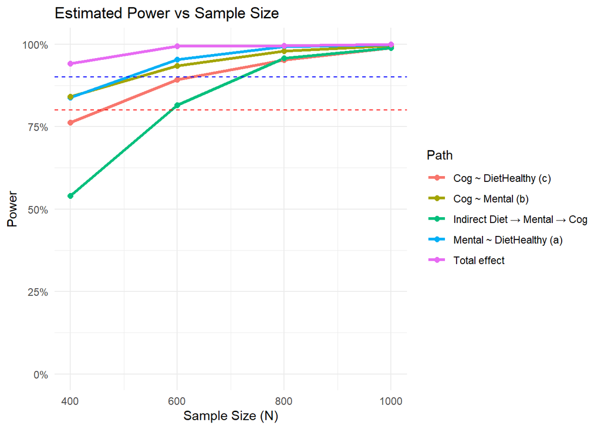

Figure 1: Estimated power by structural path across sample sizes. Dashed lines mark conventional 80% and 90% power thresholds.

```r
ggplot(power_long, aes(x = N, y = power, color = path)) +
  geom_line(linewidth = 1.2) +
  geom_point(size = 2) +
  geom_hline(yintercept = 0.8, linetype = "dashed", color = "red") +
  geom_hline(yintercept = 0.9, linetype = "dashed", color = "blue") +
  scale_y_continuous(labels = scales::percent_format(accuracy = 1), limits = c(0, 1)) +
  labs(
    title = "Estimated Power vs Sample Size",
    x = "Sample Size (N)",
    y = "Power",
    color = "Path"
  ) +
  theme_minimal()
```

## Model diagram

The diagram below shows the standardized path estimates from a representative fitted model (final replication at the largest simulated sample size), illustrating the latent measurement structure and the mediation pathway.

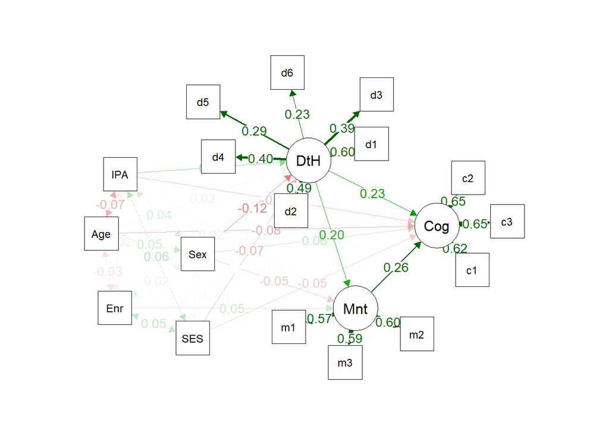

Figure 2: Standardized path diagram for the fitted latent mediation model.

```r
semPaths(
  fit_example,
  what = "std",
  layout = "spring",
  style = "mx",
  edge.label.cex = 1,
  sizeLat = 8,
  sizeMan = 6,
  residuals = FALSE,
  intercepts = FALSE
)
```